# Project: Investigate a Dataset - [Database_No_show_appointments]

- Introduction
- Data Wrangling
- Exploratory Data Analysis
- Conclusions

## Introduction

### Dataset Description

The no-show appointments dataset compiles information regarding medical appointments in Brazil, specifically focusing on patient attendance behavior. This dataset, comprising 110,527 records, aims to explore the factors influencing whether patients show up for their scheduled appointments. The data was sourced from [Kaggle](https://www.kaggle.com/datasets/joniarroba/noshowappointments), providing a comprehensive view of various aspects related to medical appointments.

The dataset encompasses **14** features for each patient, including:

- **ScheduledDay**: Tells us on what day the patient set up their appointment.
- **Neighborhood**: Indicates the location of the hospital.
- **Scholarship**: Indicates whether or not the patient is enrolled in the Brazilian welfare program [Bolsa Família](https://en.wikipedia.org/wiki/Bolsa_Fam%C3%ADlia).
- **No-show**: Indicates whether the patients showed up for their appointment or not (*No* means showed up while *Yes* means didn't show up).

The list of all features include:

|  | Feature | Dtype |
| --- | --- | --- |
| 0 | PatientId | float64 |
| 1 | AppointmentID | int64 |
| 2 | Gender | object |
| 3 | ScheduledDay | object |
| 4 | AppointmentDay | object |
| 5 | Age | int64 |
| 6 | Neighbourhood | object |
| 7 | Scholarship | int64 |
| 8 | Hipertension | int64 |
| 9 | Diabetes | int64 |
| 10 | Alcoholism | int64 |
| 11 | Handcap | int64 |
| 12 | SMS_received | int64 |
| 13 | No-show | object |

### Question(s) for Analysis

1. What is the strength and direction of the correlation between age and the date difference between scheduling and attending appointments, as measured by the Spearman correlation coefficient?
2. How does the distribution of patient age vary between attendance and absence at appointments?
3. Is there a relationship between the waiting time and the likelihood of patients attending?
4. Does sending SMS reminders to patients have a significant impact on their attendance for appointments?

```python
import pandas as pd
import numpy as np
import matplotlib.pyplot as plt
from scipy.stats import chi2_contingency
```

## Data Wrangling

```python
df=pd.read_csv('./Database_No_show_appointments/noshowappointments-kagglev2-may-2016.csv')
df.head()
```

|  | PatientId | AppointmentID | Gender | ScheduledDay | AppointmentDay | Age | Neighbourhood | Scholarship | Hipertension | Diabetes | Alcoholism | Handcap | SMS_received | No-show |
| --- | --- | --- | --- | --- | --- | --- | --- | --- | --- | --- | --- | --- | --- | --- |
| 0 | 2.987250e+13 | 5642903 | F | 2016-04-29T18:38:08Z | 2016-04-29T00:00:00Z | 62 | JARDIM DA PENHA | 0 | 1 | 0 | 0 | 0 | 0 | No |
| 1 | 5.589978e+14 | 5642503 | M | 2016-04-29T16:08:27Z | 2016-04-29T00:00:00Z | 56 | JARDIM DA PENHA | 0 | 0 | 0 | 0 | 0 | 0 | No |
| 2 | 4.262962e+12 | 5642549 | F | 2016-04-29T16:19:04Z | 2016-04-29T00:00:00Z | 62 | MATA DA PRAIA | 0 | 0 | 0 | 0 | 0 | 0 | No |
| 3 | 8.679512e+11 | 5642828 | F | 2016-04-29T17:29:31Z | 2016-04-29T00:00:00Z | 8 | PONTAL DE CAMBURI | 0 | 0 | 0 | 0 | 0 | 0 | No |
| 4 | 8.841186e+12 | 5642494 | F | 2016-04-29T16:07:23Z | 2016-04-29T00:00:00Z | 56 | JARDIM DA PENHA | 0 | 1 | 1 | 0 | 0 | 0 | No |

```python
df.tail()
```

|  | PatientId | AppointmentID | Gender | ScheduledDay | AppointmentDay | Age | Neighbourhood | Scholarship | Hipertension | Diabetes | Alcoholism | Handcap | SMS_received | No-show |
| --- | --- | --- | --- | --- | --- | --- | --- | --- | --- | --- | --- | --- | --- | --- |
| 110522 | 2.572134e+12 | 5651768 | F | 2016-05-03T09:15:35Z | 2016-06-07T00:00:00Z | 56 | MARIA ORTIZ | 0 | 0 | 0 | 0 | 0 | 1 | No |
| 110523 | 3.596266e+12 | 5650093 | F | 2016-05-03T07:27:33Z | 2016-06-07T00:00:00Z | 51 | MARIA ORTIZ | 0 | 0 | 0 | 0 | 0 | 1 | No |
| 110524 | 1.557663e+13 | 5630692 | F | 2016-04-27T16:03:52Z | 2016-06-07T00:00:00Z | 21 | MARIA ORTIZ | 0 | 0 | 0 | 0 | 0 | 1 | No |
| 110525 | 9.213493e+13 | 5630323 | F | 2016-04-27T15:09:23Z | 2016-06-07T00:00:00Z | 38 | MARIA ORTIZ | 0 | 0 | 0 | 0 | 0 | 1 | No |
| 110526 | 3.775115e+14 | 5629448 | F | 2016-04-27T13:30:56Z | 2016-06-07T00:00:00Z | 54 | MARIA ORTIZ | 0 | 0 | 0 | 0 | 0 | 1 | No |

### Dataset Exploration

```python
print(f'There are {df.shape[0]:,} records in the no show appointments dataset, and {df.shape[1]} features.')
```

```
There are 110,527 records in the no show appointments dataset, and 14 features.
```

### How many rows conating Missing vlaues?

```python
print(f' There is a {df.isnull().any().sum():,} rows with missing (Null) values')
```

```
 There is a 0 rows with missing (Null) values
```

### What is the datatype of the dataset features?

```python
df.info()
```

```
<class 'pandas.core.frame.DataFrame'>
RangeIndex: 110527 entries, 0 to 110526
Data columns (total 14 columns):
 #   Column          Non-Null Count   Dtype
---  ------          --------------   -----
 0   PatientId       110527 non-null  float64
 1   AppointmentID   110527 non-null  int64
 2   Gender          110527 non-null  object
 3   ScheduledDay    110527 non-null  object
 4   AppointmentDay  110527 non-null  object
 5   Age             110527 non-null  int64
 6   Neighbourhood   110527 non-null  object
 7   Scholarship     110527 non-null  int64
 8   Hipertension    110527 non-null  int64
 9   Diabetes        110527 non-null  int64
 10  Alcoholism      110527 non-null  int64
 11  Handcap         110527 non-null  int64
 12  SMS_received    110527 non-null  int64
 13  No-show         110527 non-null  object
dtypes: float64(1), int64(8), object(5)
memory usage: 11.8+ MB
```

### What are the number of unique values in each feature?

```python
df.nunique()
```

```
PatientId          62299
AppointmentID     110527
Gender                 2
ScheduledDay      103549
AppointmentDay        27
Age                  104
Neighbourhood         81
Scholarship            2
Hipertension           2
Diabetes               2
Alcoholism             2
Handcap                5
SMS_received           2
No-show                2
dtype: int64
```

```python
patients_schedual_more_than_one_appointment = df.nunique()[1] / df.nunique()[0] # unique AppointmentID / unique  PatientId
round(patients_schedual_more_than_one_appointment,2)
```

```
1.77
```

- The following features' types can be set to Category to optimize memory usage:
  - Neighbourhood
  - Scholarship
  - Hipertension
  - Diabetes
  - Alcoholism
  - Handcap
  - SMS_received
  - No-show
- On average, each patient has around (**1.77**) appointments scheduled. This implies that there are more appointments scheduled than there are unique patients, indicating that many patients have multiple appointments.

```python
df_noshow =df.groupby('PatientId')[['AppointmentID']].count()
```

```python
df_noshow.query('AppointmentID > 1')
```

| PatientId | AppointmentID |
| --- | --- |
| 2.263866e+07 | 2 |
| 5.216894e+07 | 2 |
| 6.485121e+07 | 2 |
| 7.922850e+07 | 2 |
| 8.799645e+07 | 2 |
| ... | ... |
| 9.996275e+14 | 4 |
| 9.997437e+14 | 2 |
| 9.998318e+14 | 4 |
| 9.998774e+14 | 2 |
| 9.999320e+14 | 5 |

24379 rows × 1 columns

**There is 24,379 patient that have made more than one appoointment.**

### Describe the dataset

```python
df.describe()
```

|  | PatientId | AppointmentID | Age | Scholarship | Hipertension | Diabetes | Alcoholism | Handcap | SMS_received |
| --- | --- | --- | --- | --- | --- | --- | --- | --- | --- |
| count | 1.105270e+05 | 1.105270e+05 | 110527.000000 | 110527.000000 | 110527.000000 | 110527.000000 | 110527.000000 | 110527.000000 | 110527.000000 |
| mean | 1.474963e+14 | 5.675305e+06 | 37.088874 | 0.098266 | 0.197246 | 0.071865 | 0.030400 | 0.022248 | 0.321026 |
| std | 2.560949e+14 | 7.129575e+04 | 23.110205 | 0.297675 | 0.397921 | 0.258265 | 0.171686 | 0.161543 | 0.466873 |
| min | 3.921784e+04 | 5.030230e+06 | -1.000000 | 0.000000 | 0.000000 | 0.000000 | 0.000000 | 0.000000 | 0.000000 |
| 25% | 4.172614e+12 | 5.640286e+06 | 18.000000 | 0.000000 | 0.000000 | 0.000000 | 0.000000 | 0.000000 | 0.000000 |
| 50% | 3.173184e+13 | 5.680573e+06 | 37.000000 | 0.000000 | 0.000000 | 0.000000 | 0.000000 | 0.000000 | 0.000000 |
| 75% | 9.439172e+13 | 5.725524e+06 | 55.000000 | 0.000000 | 0.000000 | 0.000000 | 0.000000 | 0.000000 | 1.000000 |
| max | 9.999816e+14 | 5.790484e+06 | 115.000000 | 1.000000 | 1.000000 | 1.000000 | 1.000000 | 4.000000 | 1.000000 |

Based on the provided description of the dataset, there are a few observations to note:

1. **Negative Age Values**: The minimum age value is -1, which appears to be erroneous as age cannot be negative. This could be a data entry error that needs to be addressed.
2. **Maximum Handicap Value**: The maximum value for the 'Handcap' column is 4, which may be unexpected depending on the context. Typically, binary variables like 'Handcap' would have values of either 0 or 1. It's worth verifying whether values greater than 1 are valid in this dataset or if they represent a different coding convention.
3. **PatientId and AppointmentID Data Type**: The 'PatientId' and 'AppointmentID' columns are shown in scientific notation (e.g., 1.474963e+14) in the description. While this is not inherently wrong, it's important to verify if this is the desired format for these IDs or if they should be represented differently.
4. **Outliers in Age**: While there are some outliers in the age distribution (e.g., maximum age of 115), without further context it's difficult to determine if these values are erroneous or valid.
5. **No Missing Values**: The count for all columns matches the total number of entries (110527), indicating that there are no missing values in the dataset. This is a positive sign for data completeness.

#### ُExplore Age vlaues

```python
sorted_unique_age = sorted(df['Age'].unique())
print(sorted_unique_age)
```

```
[-1, 0, 1, 2, 3, 4, 5, 6, 7, 8, 9, 10, 11, 12, 13, 14, 15, 16, 17, 18, 19, 20, 21, 22, 23, 24, 25, 26, 27, 28, 29, 30, 31, 32, 33, 34, 35, 36, 37, 38, 39, 40, 41, 42, 43, 44, 45, 46, 47, 48, 49, 50, 51, 52, 53, 54, 55, 56, 57, 58, 59, 60, 61, 62, 63, 64, 65, 66, 67, 68, 69, 70, 71, 72, 73, 74, 75, 7…
```

```python
sorted_age_counts = df['Age'].value_counts().sort_index()
print(sorted_age_counts)
```

```
-1         1
 0      3539
 1      2273
 2      1618
 3      1513
        ...
 98        6
 99        1
 100       4
 102       2
 115       5
Name: Age, Length: 104, dtype: int64
```

#### Age Data Observation

The unique values of the 'Age' column range from -1 to 115. Here are some observations:

1. **Negative Values**: The presence of a negative age value (-1) is unusual and potentially erroneous. Age is typically a non-negative integer, so a negative value could indicate a data entry error or missing data.
2. **Outliers**: The presence of very high values such as 115 could be considered outliers. While it's possible for individuals to reach such ages, it's less common and may warrant further investigation to ensure data accuracy.
3. **Zero Values**: Based on the count of rows with Zero age, we can conclude that zero means enfants with age less than 1 year.
4. The age values cover a wide range of people starting form infants to old people over 90.

#### Check Hancap value counts

```python
df.Handcap.value_counts()
```

```
0    108286
1      2042
2       183
3        13
4         3
Name: Handcap, dtype: int64
```

**The categories of the Handicap feature does not show exactly what each category is. Besides, the categories 2,3, and 4 occupy small percentage compared to 0 and 1 categories**

#### No-Show feature Exploration

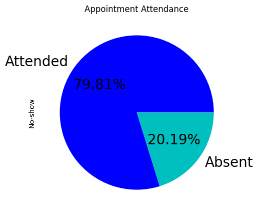

```python
df['No-show'].value_counts().plot.pie(
    labels=["Attended", "Absent"],
    colors=["b", "c"],
    autopct=lambda p: '{:.2f}%'.format(p),
    fontsize=20,
    figsize=(5, 5),
);
# Add title using Matplotlib
plt.title('Appointment Attendance');
```

### Is there any duplicate values in the no show dataset?

```python
print(f'There are {sum(df.duplicated())} duplicated records in the dataset.')
```

```
There are 0 duplicated records in the dataset.
```

### Data Cleaning

Based on the above exploration of the dataset, the following steps are needed to clean the dataset:

1. **Make features names consistent**: lower Capitlized varaible and replace dash(-) with underscore.
2. **Removing the tuple with negative age**: The choice of removing this tuple istead of using other techniques such as using median or mean is becuase there is only one record and hencse the dataset size will not be affected.
3. **Correcting the datatypes of the Object features**
4. **DataTypes Optmization**
5. **Add new Columns**:
   - Calculate the date difference between scheduled date and appotiment day.
   - Attended column instead of no-show with correct logic (1 if no-show is 0, and No otherwise)

### Step(1): Make features' names consistent

```python
# Replace '-' with '_' and convert column names to lowercase
df.columns = df.columns.str.lower().str.replace('-', '_')

# Display the modified DataFrame
df.head()
```

|  | patientid | appointmentid | gender | scheduledday | appointmentday | age | neighbourhood | scholarship | hipertension | diabetes | alcoholism | handcap | sms_received | no_show |
| --- | --- | --- | --- | --- | --- | --- | --- | --- | --- | --- | --- | --- | --- | --- |
| 0 | 2.987250e+13 | 5642903 | F | 2016-04-29T18:38:08Z | 2016-04-29T00:00:00Z | 62 | JARDIM DA PENHA | 0 | 1 | 0 | 0 | 0 | 0 | No |
| 1 | 5.589978e+14 | 5642503 | M | 2016-04-29T16:08:27Z | 2016-04-29T00:00:00Z | 56 | JARDIM DA PENHA | 0 | 0 | 0 | 0 | 0 | 0 | No |
| 2 | 4.262962e+12 | 5642549 | F | 2016-04-29T16:19:04Z | 2016-04-29T00:00:00Z | 62 | MATA DA PRAIA | 0 | 0 | 0 | 0 | 0 | 0 | No |
| 3 | 8.679512e+11 | 5642828 | F | 2016-04-29T17:29:31Z | 2016-04-29T00:00:00Z | 8 | PONTAL DE CAMBURI | 0 | 0 | 0 | 0 | 0 | 0 | No |
| 4 | 8.841186e+12 | 5642494 | F | 2016-04-29T16:07:23Z | 2016-04-29T00:00:00Z | 56 | JARDIM DA PENHA | 0 | 1 | 1 | 0 | 0 | 0 | No |

### Step(2): Remove tuples with negative age.

```python
# After discussing the structure of the data and any problems that need to be
#   cleaned, perform those cleaning steps in the second part of this section.

df.drop(df.query('age == -1').index, inplace=True)
```

```python
print(f'The number of records in the dataset after cleaning negative ages is : {df.shape[0]:,}')
```

```
The number of records in the dataset after cleaning negative ages is : 110,526
```

### Step(3): Correct datatypes

#### Convert Object representation of Object Datatime into DateTime

```python
df['scheduledday'] = pd.to_datetime(df['scheduledday']).dt.strftime('%Y-%m-%d')
df['appointmentday'] = pd.to_datetime(df['appointmentday']).dt.strftime('%Y-%m-%d')
df['appointmentday'] =  pd.to_datetime(df['appointmentday'])
df['scheduledday'] =  pd.to_datetime(df['scheduledday'])
```

#### Convert the following columns to category:

- Gender
- Scholarship
- Hipertension
- Diabetes
- Alcoholism
- Handcap
- SMS_received
- Neighbourhood

```python
columns_to_convert = ['gender', 'scholarship', 'hipertension', 'diabetes', 'alcoholism', 'handcap', 'sms_received','neighbourhood','no_show']
df[columns_to_convert] = df[columns_to_convert].astype('category')
```

### Step(4): Optimize Datatypes

```python
df['age'] = df['age'].astype('int16')
```

#### Optomize the 'AppointmentID' datatype from int64 to int32

```python
df['appointmentid'] = df['appointmentid'].astype('int32')
```

#### Optomize the 'PatientId' from float64 into float32

```python
df['patientid'] = df['patientid'].astype('float32')
```

#### check the dataset features datatypes after correcting the datatypes

```python
df.info()
```

```
<class 'pandas.core.frame.DataFrame'>
Int64Index: 110526 entries, 0 to 110526
Data columns (total 14 columns):
 #   Column          Non-Null Count   Dtype
---  ------          --------------   -----
 0   patientid       110526 non-null  float32
 1   appointmentid   110526 non-null  int32
 2   gender          110526 non-null  category
 3   scheduledday    110526 non-null  datetime64[ns]
 4   appointmentday  110526 non-null  datetime64[ns]
 5   age             110526 non-null  int16
 6   neighbourhood   110526 non-null  category
 7   scholarship     110526 non-null  category
 8   hipertension    110526 non-null  category
 9   diabetes        110526 non-null  category
 10  alcoholism      110526 non-null  category
 11  handcap         110526 non-null  category
 12  sms_received    110526 non-null  category
 13  no_show         110526 non-null  category
dtypes: category(9), datetime64[ns](2), float32(1), int16(1), int32(1)
memory usage: 4.5 MB
```

**Conclusion**:The Dataset Memory usage drops from **11.8+ MB** to **4.5 MB** after optmizing datatypes

[output not shown]

```python
df.head()
```

|  | patientid | appointmentid | gender | scheduledday | appointmentday | age | neighbourhood | scholarship | hipertension | diabetes | alcoholism | handcap | sms_received | no_show |
| --- | --- | --- | --- | --- | --- | --- | --- | --- | --- | --- | --- | --- | --- | --- |
| 0 | 2.987250e+13 | 5642903 | F | 2016-04-29 | 2016-04-29 | 62 | JARDIM DA PENHA | 0 | 1 | 0 | 0 | 0 | 0 | No |
| 1 | 5.589978e+14 | 5642503 | M | 2016-04-29 | 2016-04-29 | 56 | JARDIM DA PENHA | 0 | 0 | 0 | 0 | 0 | 0 | No |
| 2 | 4.262962e+12 | 5642549 | F | 2016-04-29 | 2016-04-29 | 62 | MATA DA PRAIA | 0 | 0 | 0 | 0 | 0 | 0 | No |
| 3 | 8.679512e+11 | 5642828 | F | 2016-04-29 | 2016-04-29 | 8 | PONTAL DE CAMBURI | 0 | 0 | 0 | 0 | 0 | 0 | No |
| 4 | 8.841186e+12 | 5642494 | F | 2016-04-29 | 2016-04-29 | 56 | JARDIM DA PENHA | 0 | 1 | 1 | 0 | 0 | 0 | No |

```python
df.info()
```

```
<class 'pandas.core.frame.DataFrame'>
Int64Index: 110526 entries, 0 to 110526
Data columns (total 14 columns):
 #   Column          Non-Null Count   Dtype
---  ------          --------------   -----
 0   patientid       110526 non-null  float32
 1   appointmentid   110526 non-null  int32
 2   gender          110526 non-null  category
 3   scheduledday    110526 non-null  datetime64[ns]
 4   appointmentday  110526 non-null  datetime64[ns]
 5   age             110526 non-null  int16
 6   neighbourhood   110526 non-null  category
 7   scholarship     110526 non-null  category
 8   hipertension    110526 non-null  category
 9   diabetes        110526 non-null  category
 10  alcoholism      110526 non-null  category
 11  handcap         110526 non-null  category
 12  sms_received    110526 non-null  category
 13  no_show         110526 non-null  category
dtypes: category(9), datetime64[ns](2), float32(1), int16(1), int32(1)
memory usage: 4.5 MB
```

### Step(5): Calculate and add date difference feature based on ScheduledDay and AppointmentDay features

```python
# Unify timezone

df['date_difference'] = (df['appointmentday'] - df['scheduledday']).dt.days

# Display the DataFrame with the new column
print(df[['scheduledday', 'appointmentday', 'date_difference']].head())
```

```
  scheduledday appointmentday  date_difference
0   2016-04-29     2016-04-29                0
1   2016-04-29     2016-04-29                0
2   2016-04-29     2016-04-29                0
3   2016-04-29     2016-04-29                0
4   2016-04-29     2016-04-29                0
```

```python
df.query('date_difference > 0')
```

|  | patientid | appointmentid | gender | scheduledday | appointmentday | age | neighbourhood | scholarship | hipertension | diabetes | alcoholism | handcap | sms_received | no_show | date_difference |
| --- | --- | --- | --- | --- | --- | --- | --- | --- | --- | --- | --- | --- | --- | --- | --- |
| 5 | 9.598514e+13 | 5626772 | F | 2016-04-27 | 2016-04-29 | 76 | REPÚBLICA | 0 | 1 | 0 | 0 | 0 | 0 | No | 2 |
| 6 | 7.336882e+14 | 5630279 | F | 2016-04-27 | 2016-04-29 | 23 | GOIABEIRAS | 0 | 0 | 0 | 0 | 0 | 0 | Yes | 2 |
| 7 | 3.449833e+12 | 5630575 | F | 2016-04-27 | 2016-04-29 | 39 | GOIABEIRAS | 0 | 0 | 0 | 0 | 0 | 0 | Yes | 2 |
| 9 | 7.812457e+13 | 5629123 | F | 2016-04-27 | 2016-04-29 | 19 | CONQUISTA | 0 | 0 | 0 | 0 | 0 | 0 | No | 2 |
| 10 | 7.345362e+14 | 5630213 | F | 2016-04-27 | 2016-04-29 | 30 | NOVA PALESTINA | 0 | 0 | 0 | 0 | 0 | 0 | No | 2 |
| ... | ... | ... | ... | ... | ... | ... | ... | ... | ... | ... | ... | ... | ... | ... | ... |
| 110522 | 2.572134e+12 | 5651768 | F | 2016-05-03 | 2016-06-07 | 56 | MARIA ORTIZ | 0 | 0 | 0 | 0 | 0 | 1 | No | 35 |
| 110523 | 3.596266e+12 | 5650093 | F | 2016-05-03 | 2016-06-07 | 51 | MARIA ORTIZ | 0 | 0 | 0 | 0 | 0 | 1 | No | 35 |
| 110524 | 1.557663e+13 | 5630692 | F | 2016-04-27 | 2016-06-07 | 21 | MARIA ORTIZ | 0 | 0 | 0 | 0 | 0 | 1 | No | 41 |
| 110525 | 9.213493e+13 | 5630323 | F | 2016-04-27 | 2016-06-07 | 38 | MARIA ORTIZ | 0 | 0 | 0 | 0 | 0 | 1 | No | 41 |
| 110526 | 3.775115e+14 | 5629448 | F | 2016-04-27 | 2016-06-07 | 54 | MARIA ORTIZ | 0 | 0 | 0 | 0 | 0 | 1 | No | 41 |

71959 rows × 15 columns

**There is 71,959 record in the dataset such that the ScheduledDay and AppointmentDay are in different days (larger than one day).**

```python
df.date_difference.describe()
```

```
count    110526.000000
mean         10.183794
std          15.255034
min          -6.000000
25%           0.000000
50%           4.000000
75%          15.000000
max         179.000000
Name: date_difference, dtype: float64
```

The average waiting time for patients from the scheduled day until the appointment day is approximately 10 days, which may be considered relatively high and could potentially be an interesting factor influencing attendance. Additionally, the minimum value of -6 days is unreasonable, while the maximum value of 179 days indicates a significantly long waiting period.

```python
# Drop rows where date_difference is less than zero
df = df[df['date_difference'] >= 0]

# Display the DataFrame after dropping rows
print(df[['scheduledday', 'appointmentday', 'date_difference']].head())
print("--------------------------------------------------")
df.date_difference.value_counts().sort_index()
```

```
  scheduledday appointmentday  date_difference
0   2016-04-29     2016-04-29                0
1   2016-04-29     2016-04-29                0
2   2016-04-29     2016-04-29                0
3   2016-04-29     2016-04-29                0
4   2016-04-29     2016-04-29                0
--------------------------------------------------
```

```
0      38562
1       5213
2       6725
3       2737
4       5290
       ...
155       10
162       11
169        8
176       16
179       10
Name: date_difference, Length: 129, dtype: int64
```

#### Step(5): Add a new column attended

This step is to replace the column no-show with attended which is easier to understand.

```python
df['attended'] = df['no_show'].apply(lambda x: 1 if x == 'No' else 0)
```

```python
# Drop the 'no_show' column from the DataFrame
df.drop('no_show', axis=1, inplace=True)
```

```python
df.head()
```

|  | patientid | appointmentid | gender | scheduledday | appointmentday | age | neighbourhood | scholarship | hipertension | diabetes | alcoholism | handcap | sms_received | date_difference | attended |
| --- | --- | --- | --- | --- | --- | --- | --- | --- | --- | --- | --- | --- | --- | --- | --- |
| 0 | 2.987250e+13 | 5642903 | F | 2016-04-29 | 2016-04-29 | 62 | JARDIM DA PENHA | 0 | 1 | 0 | 0 | 0 | 0 | 0 | 1 |
| 1 | 5.589978e+14 | 5642503 | M | 2016-04-29 | 2016-04-29 | 56 | JARDIM DA PENHA | 0 | 0 | 0 | 0 | 0 | 0 | 0 | 1 |
| 2 | 4.262962e+12 | 5642549 | F | 2016-04-29 | 2016-04-29 | 62 | MATA DA PRAIA | 0 | 0 | 0 | 0 | 0 | 0 | 0 | 1 |
| 3 | 8.679512e+11 | 5642828 | F | 2016-04-29 | 2016-04-29 | 8 | PONTAL DE CAMBURI | 0 | 0 | 0 | 0 | 0 | 0 | 0 | 1 |
| 4 | 8.841186e+12 | 5642494 | F | 2016-04-29 | 2016-04-29 | 56 | JARDIM DA PENHA | 0 | 1 | 1 | 0 | 0 | 0 | 0 | 1 |

## Exploratory Data Analysis

### Research Question 1 (What is the strength and direction of the correlation between age, and the date difference between scheduling and attending appointments, as measured by the Spearman correlation coefficient?)

```python
correlation = df[['age', 'date_difference']].corr(method='spearman', numeric_only=True)
print(correlation)
```

```
                      age  date_difference
age              1.000000         0.032977
date_difference  0.032977         1.000000
```

These results show the Spearman correlation coefficients between different variables in the dataset. Here are some observations:

- **Age and Time Difference (Date Difference)**: There is a weak positive correlation (0.032977) between age and the time difference between scheduling and attending appointments. This suggests that older patients may tend to have slightly longer waiting times between scheduling and attending appointments.

### Research Question 2 (How does the distribution of patient age vary between attendance and absence at appointments? )

```python
# Use this, and more code cells, to explore your data. Don't forget to add
#   Markdown cells to document your observations and findings.

def plot_age_vs_attendance(df ,colmname):
    """
    Plot a histogram of age distribution comparing attendance and absence.

    Parameters:
    - df (DataFrame): DataFrame containing the data.
    """
    # Create two separate DataFrames for attendance and absence
    df_attend = df[df["attended"] == 1][colmname]
    df_absent = df[df["attended"] == 0][colmname]

    # Plot histograms using pandas plot function
    ax = pd.DataFrame({'Attend': df_attend, 'Absent': df_absent}).plot.hist(bins=10, alpha=0.5)
    # Calculate the mean and standard deviation of the data
    mean_value =np.mean(df[colmname])
    std_value = np.std(df[colmname])

    # Add vertical line for the mean with mean annotation
    ax.axvline(mean_value, color='r', linestyle='--', label=f'Mean: {mean_value:.2f}')
    ax.annotate(f'Mean: {mean_value:.2f}', xy=(mean_value, 0), xytext=(0.2, 0.4),
                textcoords='axes fraction',
                arrowprops=dict(facecolor='black', arrowstyle='->'))

    # Add vertical lines for +/- 1 standard deviation from the mean
    ax.axvline(mean_value - std_value, color='g', linestyle='--', label=f'SD: {std_value:.2f}')
    ax.axvline(mean_value + std_value, color='g', linestyle='--')
        # Annotate standard deviation value
    ax.text(mean_value - std_value, 40, f'SD: {std_value:.2f}', color='g', rotation=0, ha='right')

    # Set labels and title
    ax.set_xlabel(f"{colmname}")
    ax.set_ylabel("Count of patients")
    ax.set_title(f"{colmname} vs. Attendance for patients")

    # Show legend
    ax.legend()
```

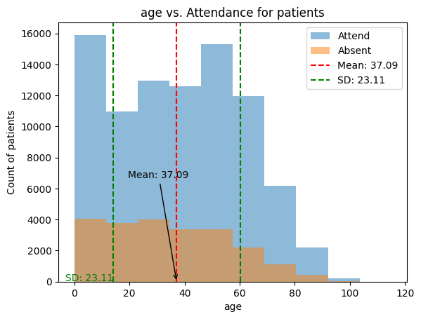

```python
plot_age_vs_attendance(df, 'age')
```

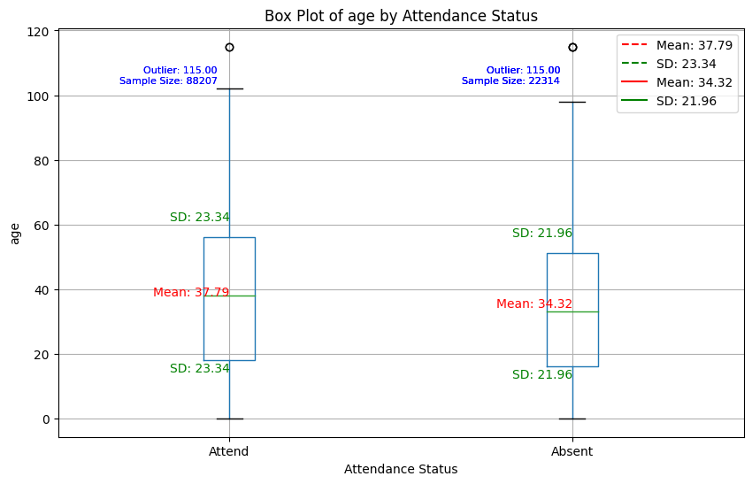

```python
def plot_age_vs_attendance(df, colname):
    """
    Plot a box plot of age distribution comparing attendance and absence.

    Parameters:
    - df (DataFrame): DataFrame containing the data.
    - colname (str): Name of the column for comparison (e.g., 'Age').
    """
    # Create two separate DataFrames for attendance and absence
    df_attend = df[df["attended"] == 1][colname]
    df_absent = df[df["attended"] == 0][colname]

    # Calculate the mean and standard deviation of the data for attendance and absence
    mean_value_attend = np.mean(df_attend)
    std_value_attend = np.std(df_attend)
    mean_value_absent = np.mean(df_absent)
    std_value_absent = np.std(df_absent)

    # Create a box plot
    plt.figure(figsize=(10, 6))
    df_boxplot = pd.DataFrame({'Attend': df_attend, 'Absent': df_absent})
    boxplot = df_boxplot.boxplot(showfliers=True, return_type='dict')

    # Annotate mean and standard deviation for attendance
    plt.text(1, mean_value_attend, f'Mean: {mean_value_attend:.2f}', color='r', fontsize=10, ha='right')
    plt.text(1, mean_value_attend - std_value_attend, f'SD: {std_value_attend:.2f}', color='g', fontsize=10, ha='right')
    plt.text(1, mean_value_attend + std_value_attend, f'SD: {std_value_attend:.2f}', color='g', fontsize=10, ha='right')

    # Annotate mean and standard deviation for absence
    plt.text(2, mean_value_absent, f'Mean: {mean_value_absent:.2f}', color='r', fontsize=10, ha='right')
    plt.text(2, mean_value_absent - std_value_absent, f'SD: {std_value_absent:.2f}', color='g', fontsize=10, ha='right')
    plt.text(2, mean_value_absent + std_value_absent, f'SD: {std_value_absent:.2f}', color='g', fontsize=10, ha='right')

    # Annotate outliers and sample size
    for i, (outlier, sample_size) in enumerate(zip(boxplot['fliers'], [len(df_attend), len(df_absent)])):
        for j, value in enumerate(outlier.get_ydata()):
            plt.annotate(f'Outlier: {value:.2f}\nSample Size: {sample_size}', xy=(i + 1, value), xytext=(-10, -30),
                         textcoords='offset points', ha='right', fontsize=8, color='b')

    # Set legend labels and line styles
    legend_labels = [f'Mean: {mean_value_attend:.2f}', f'SD: {std_value_attend:.2f}',
                     f'Mean: {mean_value_absent:.2f}', f'SD: {std_value_absent:.2f}']
    legend_lines = [plt.Line2D([0], [0], color='r', linestyle='--'),  # Mean line
                    plt.Line2D([0], [0], color='g', linestyle='--'),  # SD lines
                    plt.Line2D([0], [0], color='r', linestyle='-'),  # Mean line
                    plt.Line2D([0], [0], color='g', linestyle='-')]  # SD lines

    # Show legend with custom labels and line styles
    plt.legend(legend_lines, legend_labels, loc='best')

    # Set labels and title
    plt.xlabel("Attendance Status")
    plt.ylabel(colname)
    plt.title(f"Box Plot of {colname} by Attendance Status")

    # Show plot
    plt.show()

# Example usage
plot_age_vs_attendance(df, 'age')
```

### Research Question3 (Is there a relationship between the waiting time and the likelihood of patients' attending?)

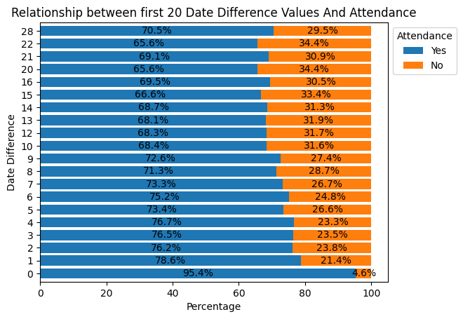

```python
# Select the top 20 date_difference values
top_20_date_difference = df['date_difference'].value_counts().nlargest(20).index

# Filter the DataFrame to include only the top 20 date_difference values
df_top_20 = df[df['date_difference'].isin(top_20_date_difference)]

# Group the filtered data by 'date_difference' and 'attended', and count the occurrences
grouped_data = df_top_20.groupby(['date_difference', 'attended']).size().unstack()

# Normalize the data to make it stacked 100%
normalized_data = grouped_data.div(grouped_data.sum(axis=1), axis=0) * 100

# Set the figure size
plt.figure(figsize=(12, 8))  # Adjust the values as needed

# Plot the normalized data as a stacked horizontal bar chart
ax = normalized_data.plot(kind='barh', stacked=True, width=0.8)  # Set width to ensure full stacking

# Add labels and title
plt.xlabel('Percentage')
plt.ylabel('Date Difference')
plt.title('Relationship between first 20 Date Difference Values And Attendance')

# Add percentage values on the bars
for p in ax.patches:
    width = p.get_width()
    height = p.get_height()
    x, y = p.get_xy()
    ax.annotate(f'{width:.1f}%', (x + width/2, y + height/2), ha='center', va='center')
legend_labels = ['Yes', 'No']
# Place legend outside the graph
plt.legend(legend_labels ,title='Attendance', loc='upper left', bbox_to_anchor=(1, 1))

# Show the plot
plt.show()
```

**Observations:**

- Generally, the percentage of patients attending appointments seems to decrease as the date difference increases (more days since scheduled visit).
  - For example, around 95% of patients attended appointments with a 0-day difference, whereas attendance dips to around 65% or appointments with a 20-day difference.
  - There are a few exceptions to this trend. For instance, attendance appears slightly higher for a 9-day difference compared to an 8-day difference.

Overall, the graph suggests a possible negative correlation between waiting time (date difference) and attendance. As the waiting time increases, the likelihood of patients attending appears to decrease.

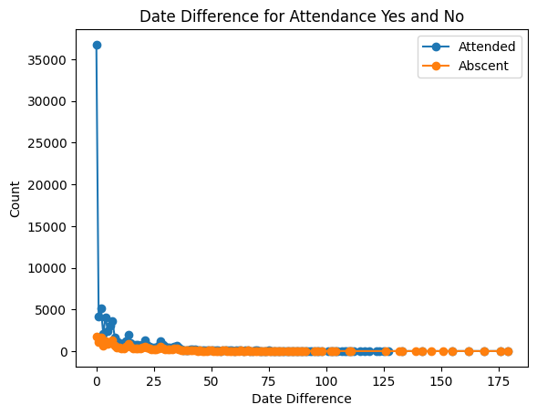

```python
# Filter DataFrame for 'attended' values of '1' and '0'
df_yes = df[df['attended'] == 1]
df_no = df[df['attended'] == 0]

# Group data by 'date_difference' and count occurrences for 'Yes' and 'No'
grouped_data_yes = df_yes['date_difference'].value_counts().sort_index()
grouped_data_no = df_no['date_difference'].value_counts().sort_index()

# Plot line chart for 'Yes' and 'No' no_show values
ax = grouped_data_yes.plot(kind='line', marker='o', label='Attended')
grouped_data_no.plot(kind='line', marker='o', ax=ax, label='Abscent')

# Add labels and title
plt.xlabel('Date Difference')
plt.ylabel('Count')
plt.title('Date Difference for Attendance Yes and No')

# Show the legend
plt.legend()

# Show the plot
plt.show()
```

The line graph indicates that the frequency of attending patients with zero wait time is the highest, exceeding 35,000. However, this sharply declines when the waiting time extends beyond one day, stabilizing thereafter for both attendance and absence groups.

### Research Question 4 Does sending SMS reminders to patients have a significant impact on their attendance for appointments?

```python
# Create a contingency table of sms_received and no_show
contingency_table = pd.crosstab(df['sms_received'], df['attended'])

# Perform chi-square test
chi2_stat, p_value, _, _ = chi2_contingency(contingency_table)

# Print the results
print("Chi-square statistic: {:.2f}".format(chi2_stat))

print("P-value:", p_value)
```

```
Chi-square statistic: 1767.98
P-value: 0.0
```

The output you provided suggests a statistically significant relationship between receiving an SMS and patient attendance.

- **Chi-square statistic:** 1767.98
- **P-value:** 0.0

**Interpretation:**

- A high chi-square statistic (usually above 3.84 for a significance level of 0.05) indicates a rejection of the null hypothesis, which states that there's no association between the variables. In this case, the value is very high, suggesting we can reject the null hypothesis.
- A p-value of 0.0 signifies a very low probability (less than 0.05) of observing this chi-square statistic by random chance. This strengthens the evidence that a real connection exists between receiving an SMS and attendance.

## Conclusions

Beginning with a comprehensive examination of the dataset, we identified a total of 110,527 records in the no-show appointments dataset, encompassing 14 features. Notably, there were no missing (null) values within the dataset, indicating its robustness for analysis. Through meticulous cleaning and preparation, the dataset was optimized to address the research questions outlined in the introduction.

### Limitation:

**Class Imbalance:**

The class imbalance between patients who attended (88207) and those who didn't (22314) can be a limitation in Exploratory Data Analysis (EDA) and statistical testing in a few ways:

1. **Misleading Visualizations**:
   - *Distribution Skew*: Histograms, box plots, and other visualizations that rely on distribution can be skewed towards the majority class ("attended"). This can mask patterns or trends present in the minority class ("not attended").
2. **Statistical Test Inapplicability**:
   - *Assumption Violations*: Many statistical tests assume a normal distribution of data for both classes. With a significant imbalance, normality might not hold for the minority class, rendering the tests unreliable.
3. **Limited Insights**:
   - *Focus on Majority*: EDA techniques might inadvertently focus on understanding the "attended" group due to its overwhelming presence. This can lead to overlooking important information about the factors influencing non-attendance.

**Data Types:**

Finally, Moving forward, further research could delve into the specific factors contributing to attendance patterns, such as socioeconomic factors, health conditions, or geographical location. Additionally, incorporating qualitative data or patient feedback could provide deeper insights into attendance behavior and help inform strategies to improve appointment attendance rates.

```python
# Running this cell will execute a bash command to convert this notebook to an .html file
!python -m nbconvert --to html Investigate_a_Dataset.ipynb
```

```
[NbConvertApp] Converting notebook Investigate_a_Dataset.ipynb to html
[NbConvertApp] WARNING | Alternative text is missing on 5 image(s).
[NbConvertApp] Writing 682773 bytes to Investigate_a_Dataset.html
```

```python
#df.to_csv('modified_data.csv', index=False)
```